# BHHU-ATRA Database Fixes — Action List

Issues in the source Excel database that require manual correction

Published

July 20, 2026

## Purpose

This report surfaces specific data quality issues in `Database/baza_gdrive.xlsx` that **cannot be fixed by the pipeline** and require manual correction by the ATRA data team. It complements the *Data Quality Report* (`02_quality.qmd`), which covers pipeline validation flags and DwC readiness.

Each section identifies the affected records so they can be located and corrected in the Excel file directly. All tables are searchable and paginated.

## Issue summary

| Issue | Affected records | % of database | Priority |
| --- | --- | --- | --- |
| Taxon name not in reference list | 7285 | 61.7% | High |
| Unknown month value | 272 | 2.3% | High |
| Month recorded as date range (e.g. Maj–Oktobar) | 23 | 0.2% | Medium |
| Unknown basisOfRecord value | 0 | 0.0% | High |
| Duplicate record ID | 0 | 0.0% | High |
| Impossible date (day out of range) | 5 | 0.0% | Medium |
| Coordinates outside BiH bounding box | 42 | 0.4% | Low |
| Coordinates missing | 295 | 2.5% | Low |

## Missing data overview (naniar)

Both empty cells and `"n/a"` strings are treated as missing for this analysis.

### Missing values per column

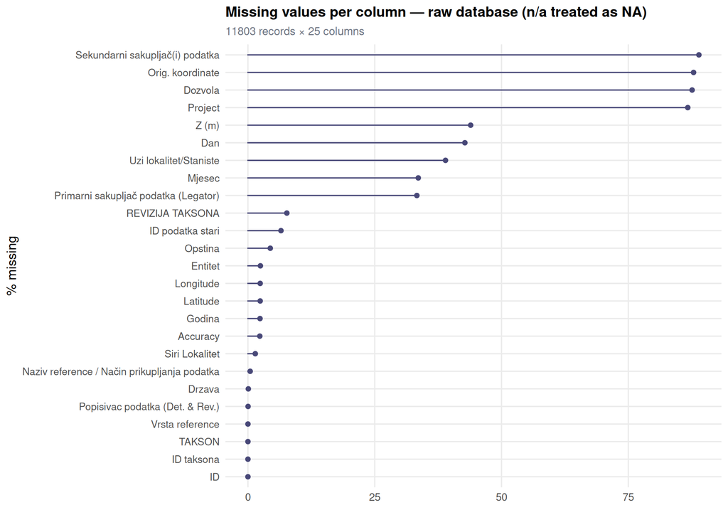

### Field missingness table

| Column | Missing (n) | Missing (%) |
| --- | --- | --- |
| Sekundarni sakupljač(i) podatka | 10495 | 88.9 |
| Orig. koordinate | 10371 | 87.9 |
| Dozvola | 10337 | 87.6 |
| Project | 10236 | 86.7 |
| OSTALE INFORMACIJE/KRATKI IZVJEŠTAJ/NAPOMENE/MIŠLJENJA/REVIZIJE/ISPRAVKE/POVEZANOST SA OSTALIM BAZAMA (ID) | 8361 | 70.8 |
| Z (m) | 5183 | 43.9 |
| Dan | 5049 | 42.8 |
| Uzi lokalitet/Staniste | 4598 | 39 |
| Mjesec | 3964 | 33.6 |
| Primarni sakupljač podatka (Legator) | 3931 | 33.3 |

[output cut: 12 more lines]

### Missingness heatmap

Each row is one record; each column is one field. Black = missing, grey = present.

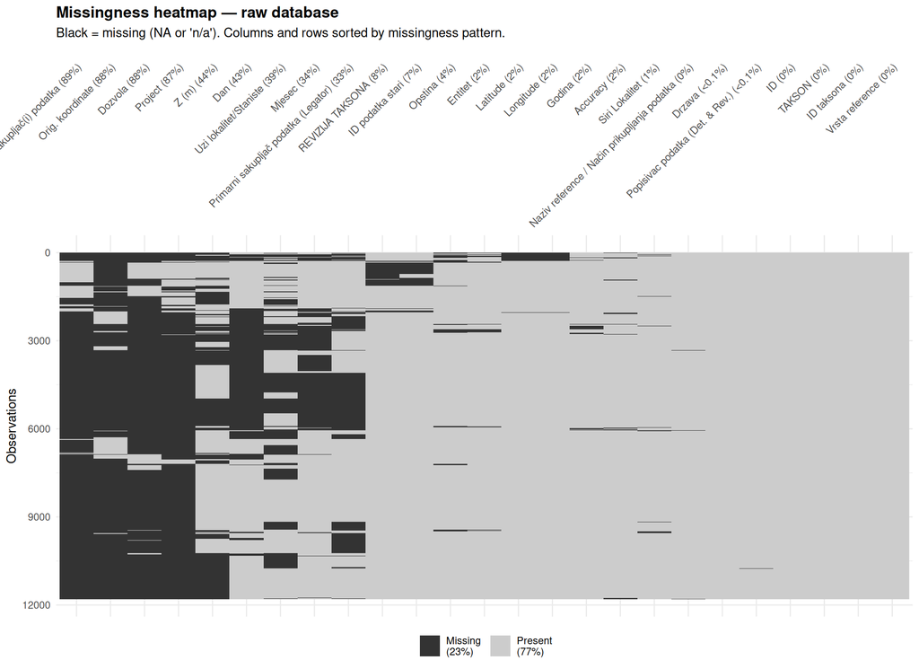

## Taxon name anomalies

`TAKSON` values that do not exactly match any entry in the `2_ID taksona` reference sheet — likely spelling mistakes, outdated synonyms, or variants not yet added to the reference.

> **Fix:** Correct the spelling in `TAKSON` **or** add the variant to `2_ID taksona` as an accepted synonym.

### By name (frequency)

| TAKSON (not in reference list) | Records |
| --- | --- |
| Podarcis muralis | 804 |
| Lacerta viridis | 675 |
| Vipera ammodytes | 623 |
| Anguis fragilis | 432 |
| Ichthyosaura alpestris | 305 |
| Coronella austriaca | 280 |
| Natrix tessellata | 266 |
| Lacerta agilis | 223 |
| Podarcis melisellensis | 217 |
| Natrix natrix | 208 |

[output cut: 274 more lines]

### Full record list

| ID podatka | TAKSON | Godina nalaza | Vrsta reference |
| --- | --- | --- | --- |
| 10927.0 | Ablepharus kitaibelii | 2025.0 | Terenski podaci |
| 4985.0 | Ablepharus kitaibelii | 2018.0 | Literaturni podaci |
| 4986.0 | Ablepharus kitaibelii | 2018.0 | Literaturni podaci |
| 4987.0 | Ablepharus kitaibelii | 1978.0 | Literaturni podaci |
| 4988.0 | Ablepharus kitaibelii | 1954.0 | Literaturni podaci |
| 8649.0 | Ablepharus kitaibelii | 2012.0 | Literaturni podaci |
| 8371.0 | Algiroides nigropuncatus | 1941.0 | Literaturni podaci |
| 8399.0 | Algiroides nigropunctuatus | 1911.0 | Literaturni podaci |
| 8400.0 | Algiroides nigropunctuatus | 1912.0 | Literaturni podaci |
| 8401.0 | Algiroides nigropunctuatus | 1912.0 | Literaturni podaci |

[output cut: 7275 more lines]

## Vocabulary issues

### Month field (`Mjesec nalaza`) — unknown values

Values not in the month dictionary — they cannot be parsed and produce year-only `eventDate` records.

> **Fix:** Replace with the correct standard Bosnian month name (Januar … Decembar).

| Unknown month value | Records |
| --- | --- |
| Jul | 143 |
| Jun | 92 |
| April-Septembar | 19 |
| Unknown | 9 |
| Apj | 1 |
| Apri. | 1 |
| April/Maj | 1 |
| April/Septembar | 1 |
| Bar | 1 |
| Ma. | 1 |

[output cut: 3 more lines]

### Month field — date ranges

Records where `Mjesec nalaza` contains a range (e.g. `Maj-Oktobar`). A single month cannot be derived, so `eventDate` is year-only.

> **Fix:** Leave the month blank and move the range to `NAPOMENE`, or record the start month only.

| Range value | Records |
| --- | --- |
| April-Septembar | 19 |
| April/Maj | 1 |
| April/Septembar | 1 |
| Maj-Oktobar | 1 |
| Maj/Juni | 1 |

### basisOfRecord (`Vrsta reference`) — unknown values

> **Fix:** Replace with one of the accepted terms: *Terenski podaci*, *Literaturni podaci*, *Podaci iz izvještaja*, *Podaci iz zooloških kolekcija*, *Kolekcija ZMS*, *Ostalo*.

```
No unknown basisOfRecord values detected.
```

### Country field (`Drzava`) — variant spellings

Multiple abbreviations are in use for the same country. The pipeline maps all known variants, but a single standard should be enforced in the database.

> **Fix:** Standardise to ISO 3166-1 alpha-2: `BA` (BiH), `HR` (Croatia), `ME` (Montenegro), `RS` (Serbia), `AL` (Albania), `BG` (Bulgaria), `HU` (Hungary), `GR` (Greece). Apply an Excel dropdown to enforce this going forward.

| Drzava | Records |
| --- | --- |
| B&H | 11588 |
| CRO | 100 |
| MNE | 34 |
| HR | 32 |
| ME | 19 |
| SRB | 9 |
| ALB | 3 |
| RS | 3 |
| BUG | 2 |
| CG | 1 |

[output cut: 3 more lines]

## Date issues

### Impossible dates

Day value is out of range for the given month (e.g. day 31 in April).

> **Fix:** Correct the day value, or clear the day and leave year + month only.

| ID podatka | TAKSON | Dan nalaza | Mjesec nalaza | Godina nalaza |
| --- | --- | --- | --- | --- |
| 4227.0 | Bombina variegata | 45844.0 | Maj | 1989.0 |
| 6278.0 | Vipera ammodytes | 34.0 | Juni | 2023.0 |
| 6507.0 | Vipera ammodytes | 45994.0 | August | 2001.0 |
| 7179.0 | Natrix tessellata | 33.0 | Juni | 2023.0 |
| 7292.0 | Tropidonotus tessellatus | 31.0 | Juni | 1918.0 |

## Coordinate issues

### Records outside the BiH bounding box

Coordinates are outside the expected range (lat 42–46°N, lon 15.7–19.7°E). May be legitimate records from neighbouring countries or coordinate entry errors.

> **Fix:** Verify the coordinates and confirm `Drzava` matches. Correct or blank the coordinates if they are wrong.

| ID podatka | TAKSON | Latitude | Longitude | Drzava | Godina nalaza |
| --- | --- | --- | --- | --- | --- |
| 10012.0 | Rana graeca | 39.84772 | 21.91426 | GRC | 1985.0 |
| 10010.0 | Rana graeca | 41.60776 | 20.38413 | ALB | 2003.0 |
| 10011.0 | Rana graeca | 41.79 | 20.19 | ALB | 2003.0 |
| 10009.0 | Rana graeca | 41.90066 | 20.39794 | ALB | 2003.0 |
| 31.0 | Salamandra salamandra | 42.882206 | 22.247500 | SRB | 2022.0 |
| 3597.0 | Lacerta viridis | 43.144858 | 20.512504 | SRB | 2021.0 |
| 7276.0 | Natrix tessellata | 43.218954 | 19.717833 | RS | 2020.0 |
| 3603.0 | Lacerta viridis | 43.229724 | 19.716167 | SRB | 2021.0 |
| 535.0 | Vipera berus | 43.267169 | 20.828755 | SRB | 1920.0 |
| 536.0 | Vipera berus | 43.616542 | 25.350628 | BUG | 1920.0 |

[output cut: 32 more lines]

## Duplicate record IDs

Records that share an `ID podatka` with at least one other record.

> **Fix:** Assign unique IDs to the duplicates. Contact the pipeline team first — ID changes affect `occurrenceID` stability.

```
No duplicate IDs detected.
```

## Actionable to-do list

Items marked **High** block clean Darwin Core output or GBIF submission.

| # | Priority | Issue | What to do |
| --- | --- | --- | --- |
| 1 | High | Taxon names not in reference list | 7285 records — correct spelling or add to 2_ID taksona |
| 2 | High | Duplicate record IDs | 0 IDs — assign unique values (coordinate with pipeline team) |
| 3 | High | Unknown basisOfRecord (Vrsta reference) | 0 records — replace with an accepted vocabulary term |
| 4 | High | Unknown month values | 272 records — replace typos with standard Bosnian month names |
| 5 | Medium | Impossible dates (day out of range) | 5 records — correct the day value or clear it |
| 6 | Medium | Month recorded as date range (e.g. Maj–Oktobar) | 23 records — move range to NAPOMENE; record start month only |
| 7 | Medium | Country abbreviation variants | Standardise Drzava to ISO 3166-1 alpha-2; apply Excel dropdown |
| 8 | Low | Coordinates outside BiH bounding box | 42 records — verify coordinates and Drzava field |
| 9 | Low | "n/a" strings used as missing values | Replace all 'n/a' text with empty cells across 20+ columns |
| 10 | Low | REVIZIJA TAKSONA 2025 — column purpose ambiguous | Rename to reflect actual content; add separate revised-name column |

*Generated from `Database/baza_gdrive.xlsx` via the ATRA targets pipeline.* *See `Database/to_improve.md` for the full structural improvement recommendations.*